# Final Project: Predicting Airbnb Prices

December 10, 2018

## Bringing in the data

```r
train <- read.csv('C:/Users/student/Desktop/train.csv', header = TRUE)
str(train)
```

```
## 'data.frame':    74111 obs. of  29 variables:
##  $ id                    : int  6901257 6304928 7919400 13418779 3808709 12422935 11825529 13971273 180792 5385260 ...
##  $ log_price             : num  5.01 5.13 4.98 6.62 4.74 ...
##  $ property_type         : Factor w/ 35 levels "Apartment","Bed & Breakfast",..: 1 1 1 18 1 1 1 12 18 18 ...
##  $ room_type             : Factor w/ 3 levels "Entire home/apt",..: 1 1 1 1 1 2 1 1 2 2 ...
##  $ amenities             : Factor w/ 67122 levels "{\"Air conditioning\",\"Carbon monoxide detector\",\"First aid kit\",\"Lock on bedroom door\",\"translation mis"| __truncated__,..: 6155 6282 21347 38856 55415 50087 63353 22672 22641 3787 ...
##  $ accommodates          : int  3 7 5 4 2 2 3 2 2 2 ...
##  $ bathrooms             : num  1 1 1 1 1 1 1 1 1 1 ...
##  $ bed_type              : Factor w/ 5 levels "Airbed","Couch",..: 5 5 5 5 5 5 5 5 5 5 ...
##  $ cancellation_policy   : Factor w/ 5 levels "flexible","moderate",..: 3 3 2 1 2 3 2 2 2 2 ...
##  $ cleaning_fee          : Factor w/ 2 levels "False","True": 2 2 2 2 2 2 2 2 2 2 ...
##  $ city                  : Factor w/ 6 levels "Boston","Chicago",..: 5 5 5 6 3 6 4 4 6 4 ...
##  $ description           : Factor w/ 73479 levels "'And tell me what street compares with Mott St in July'' Soak in the old streets of New York, My place is close"| __truncated__,..: 10463 19852 57934 64207 16642 9655 68883 7704 22123 49845 ...
##  $ first_review          : Factor w/ 2555 levels "","2008-11-17",..: 2081 2494 2397 1 1678 2516 2346 2262 1955 2370 ...
##  $ host_has_profile_pic  : Factor w/ 3 levels "","f","t": 3 3 3 3 3 3 3 3 3 3 ...
##  $ host_identity_verified: Factor w/ 3 levels "","f","t": 3 2 3 3 3 3 2 3 2 2 ...
##  $ host_response_rate    : Factor w/ 81 levels "","0%","10%",..: 1 4 4 1 4 4 4 4 4 4 ...
##  $ host_since            : Factor w/ 3088 levels "","2008-03-03",..: 1071 2982 2745 2190 2141 2970 2874 1489 2236 2883 ...
##  $ instant_bookable      : Factor w/ 2 levels "f","t": 1 2 2 1 2 2 2 1 1 2 ...
##  $ last_review           : Factor w/ 1372 levels "","2009-01-21",..: 928 1360 1351 1 1116 1342 1205 1196 1361 1200 ...
##  $ latitude              : num  40.7 40.8 40.8 37.8 38.9 ...
##  $ longitude             : num  -74 -74 -73.9 -122.4 -77 ...
##  $ name                  : Factor w/ 73359 levels "'57 Airstream Trailer on Urban Farm",..: 9562 67234 67907 9807 33057 20293 8625 46582 23830 48047 ...
##  $ neighbourhood         : Factor w/ 620 levels "","16th Street Heights",..: 79 254 249 327 121 393 1 151 458 1 ...
##  $ number_of_reviews     : int  2 6 10 0 4 3 15 9 159 2 ...
##  $ review_scores_rating  : num  100 93 92 NA 40 100 97 93 99 90 ...
##  $ thumbnail_url         : Factor w/ 65884 levels "","https://a0.muscache.com/im/pictures/0000ec1e-e6de-4c4b-b244-be89b344267b.jpg?aki_policy=small",..: 32400 16222 32854 33694 1 38396 22762 29022 2968 41863 ...
##  $ zipcode               : Factor w/ 770 levels ""," ","02108",..: 197 76 86 750 343 762 531 444 753 692 ...
##  $ bedrooms              : num  1 3 1 2 0 1 1 1 1 1 ...
##  $ beds                  : num  1 3 3 2 1 1 1 1 1 1 ...
```

## Showing Target Variable (Price)

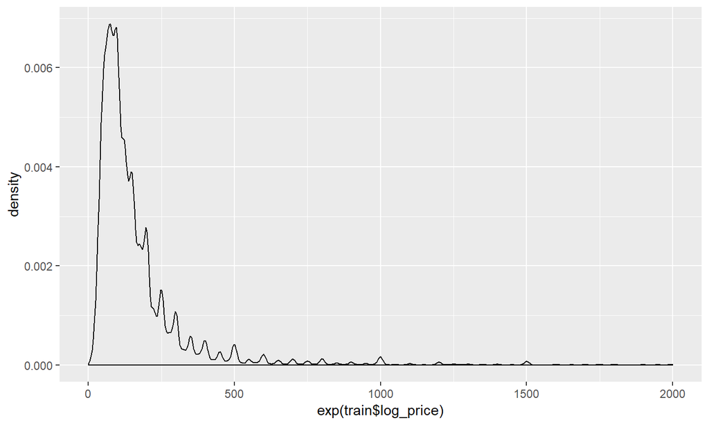

```r
library(ggplot2)
print(ggplot(train) + geom_density(mapping = aes(x= exp(train$log_price))))
```

## Mean of Target

```r
train$log_price = exp(train$log_price)

mean(train$log_price)
```

```
## [1] 160.3708
```

## Making the Target a 2-level Factor

-Switched log_price from a numeric to factor -Split the variable at the mean: - "<160" - ">160"

```
##
##  <160  >160
## 51716 22395
```

## Disposing Excess Variables, Recoding levels

-Took out many variables including:

-Last review date, id#, thumbnail URL, host since, cancellation policy, description, neighbourhood, name, first review, zipcode, latitude, longitude, and amenities(too many levels)

-Cut down the levels of categorical variables including:

-host response rate (100, not 100), bed type (bed, not a bed), property type (house, apartment, other), identity verified (T/F), profile pic of host (T/F), instant bookable(T/F)

## Graphs

- Showing the distribution of the target variable

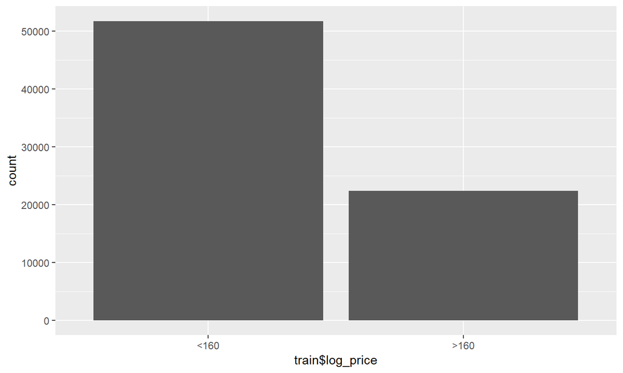

```r
print(ggplot(train) + geom_bar(mapping = aes(x= train$log_price)))
```

## Graphs

- Property type follows the same trends in both sides

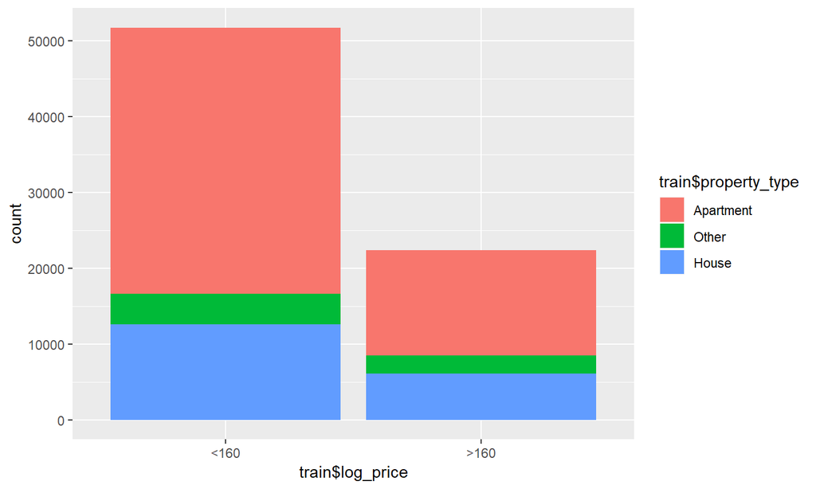

```r
print(ggplot(train) + geom_bar(mapping = aes(x= train$log_price, fill = train$property_type)))
```

## Graphs

-Most of >160 is "entire home/apt"

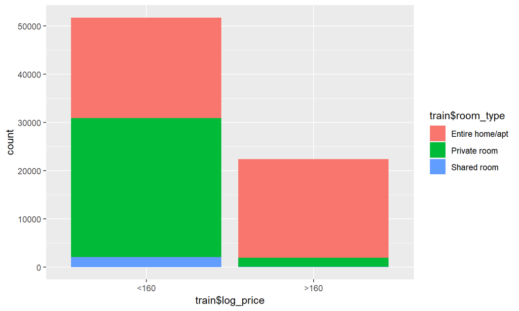

```r
print(ggplot(train) + geom_bar(mapping = aes(x= train$log_price, fill = train$room_type)))
```

## Graphs

-We can see that there are 10 bed listings for <160

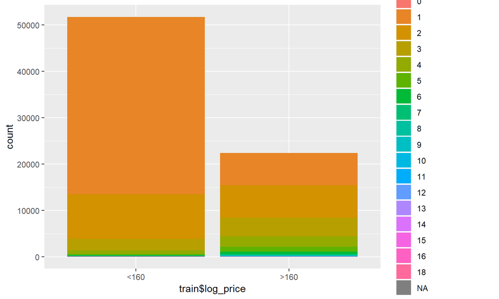

```r
print(ggplot(train) + geom_bar(mapping = aes(x= train$log_price, fill = as.factor(train$beds))))
```

## Closer look

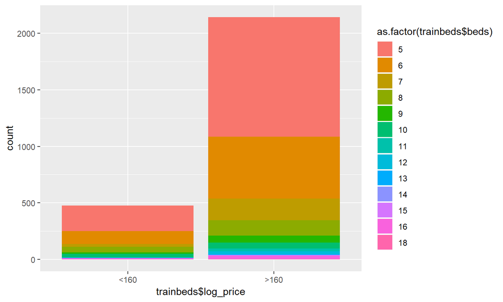

```r
trainbeds <- subset(train, train$beds >= 5)
print(ggplot(trainbeds) + geom_bar(mapping = aes(x= trainbeds$log_price, fill = as.factor(trainbeds$beds))))
```

## Graphs

-A very big portion of the listings for <160 are 1 bedroom.

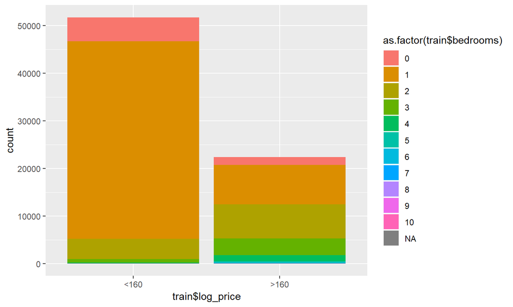

```r
print(ggplot(train) + geom_bar(mapping = aes(x= train$log_price, fill = as.factor(train$bedrooms))))
```

## Graphs

-probability of <160 very close to that of >160 at beds=2

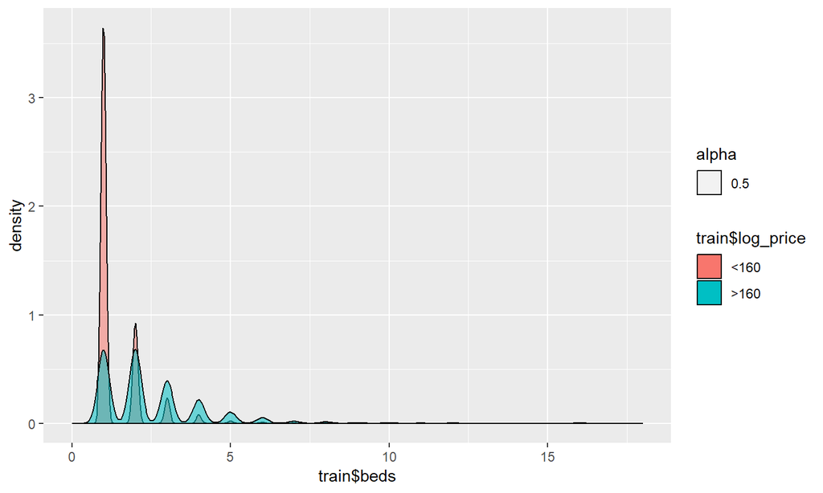

```r
print(ggplot(train) + geom_density(mapping = aes(x= train$beds, fill = train$log_price, alpha = .5)))
```

## Graphs

-Almost everyone has a profile picture, no matter identity

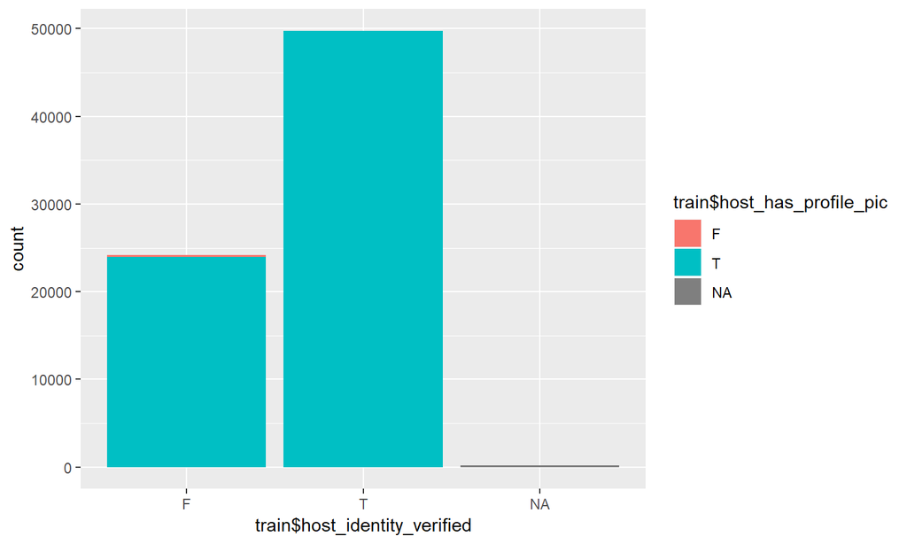

```r
print(ggplot(train) + geom_bar(mapping = aes(x= train$host_identity_verified, fill = train$host_has_profile_pic)))
```

## Graphs

-Probably <160 for 1 bedroom, probably >160 for 2 bedrooms

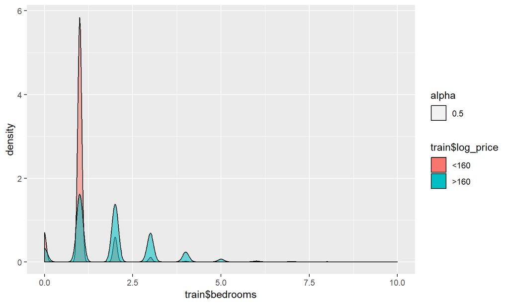

```r
print(ggplot(train) + geom_density(mapping = aes(x= train$bedrooms, fill = train$log_price, alpha = .5)))
```

## Graphs

-No relation between number of reviews to pricing.

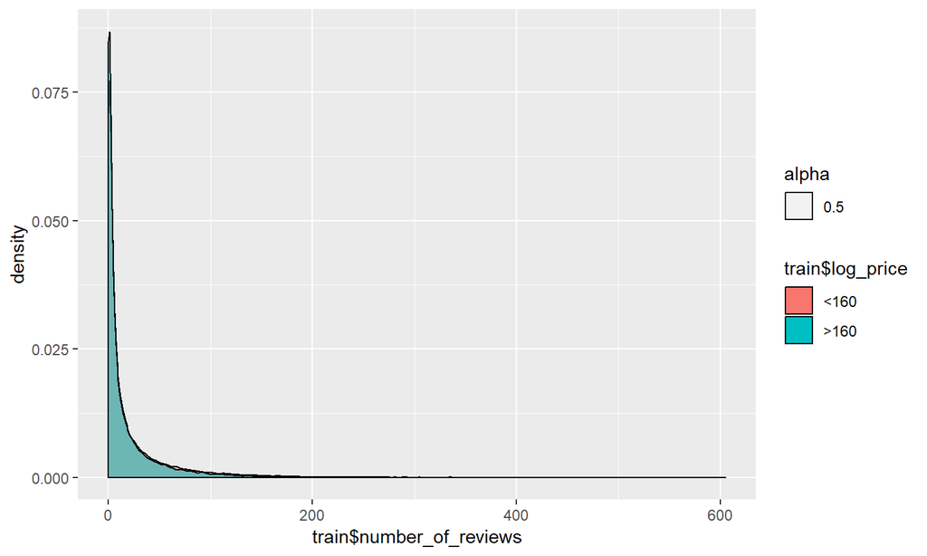

```r
print(ggplot(train) + geom_density(mapping = aes(x= train$number_of_reviews, fill = train$log_price, alpha = .5)))
```

## Graphs

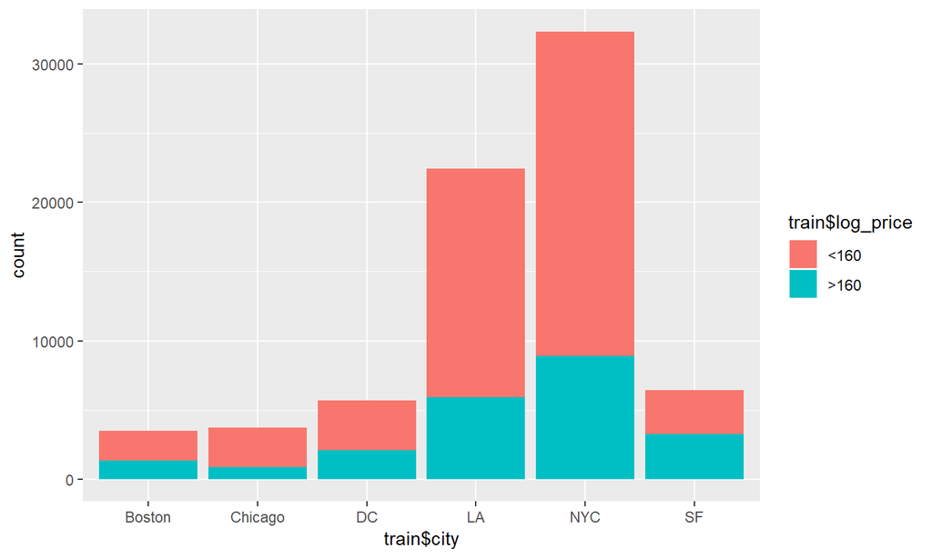

```r
print(ggplot(train) + geom_bar(mapping = aes(x = train$city, fill = train$log_price)))
```

## Graphs

-Over 100 reviews, score rating >= 70

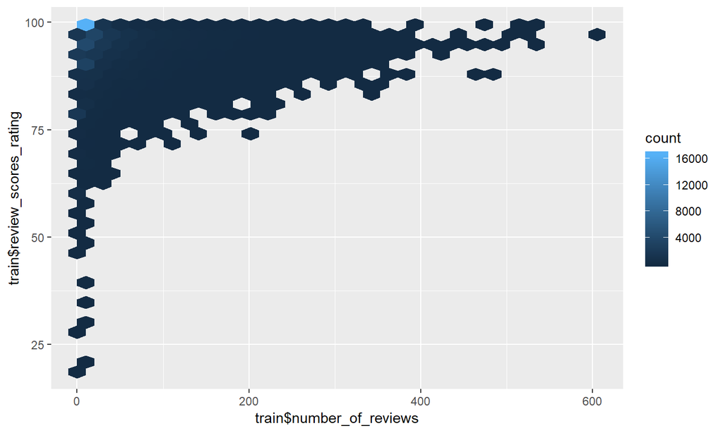

```r
library(hexbin)
print(ggplot(train) + geom_hex(mapping = aes(x = train$number_of_reviews, y = train$review_scores_rating)))
```

## Graphs

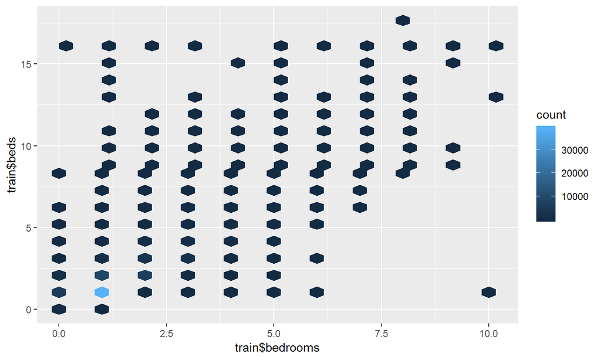

```r
print(ggplot(train) + geom_hex(mapping = aes(x = train$bedrooms, y = train$beds)))
```

## Graphs

-If you have a 100 response rate, more reviews will lead to higher score

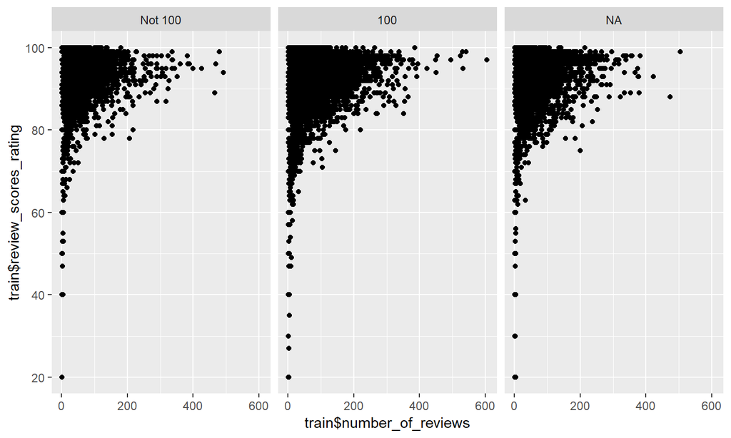

```r
print(ggplot(train) + geom_point(mapping = aes(x = train$number_of_reviews, y = train$review_scores_rating)) + facet_wrap(~ train$host_response_rate))
```

## Graphs

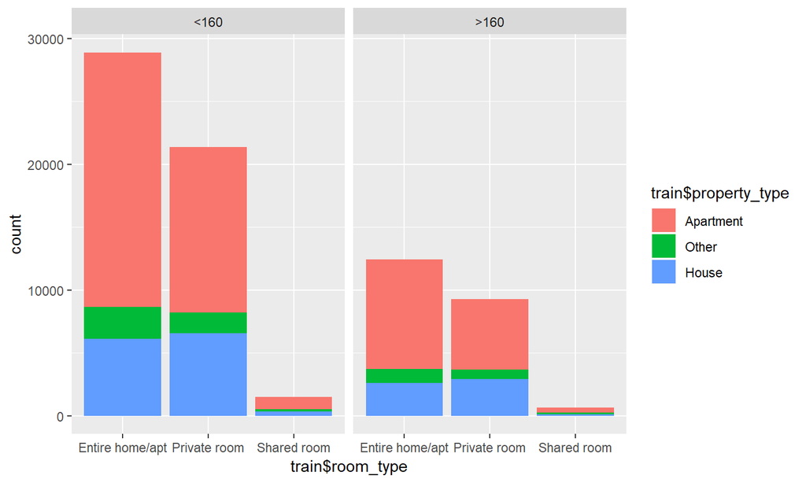

```r
print(ggplot(train) + geom_bar(mapping = aes(x = train$room_type, fill = train$property_type)) + facet_wrap(~ train$log_price))
```

## Notes

-I expected to see less "entire home/apt" listings for the <160 chart

-I also expected to see less apartments for the "entire home/apt"" listings at the >160 level.

## Clean dataset of NA's (mean and mode)

```
## [1] 0
```

## Clean dataset of NA's (removing rows with missing data)

```
## [1] 0
```

## Split the data

-Partitioning the data

```r
library(caret)
splitIndex <- createDataPartition(train.clean1$log_price, p = .70, list = FALSE, times = 1)
training <- train.clean1[ splitIndex,]
test <- train.clean1[-splitIndex,]

splitIndex2 <- createDataPartition(train.clean3$log_price, p = .70, list = FALSE, times = 1)
training2 <- train.clean3[ splitIndex2,]
test2 <- train.clean3[-splitIndex2,]
```

## Recoding categoical variables

-Recoded categorical variables with dummyVars

## Caret model (training1 - No dummVars)

## Results

```r
cm$overall[1]
```

```
##  Accuracy
## 0.8036164
```

```r
cm$byClass[11]
```

```
## Balanced Accuracy
##         0.7330321
```

## Caret model (training2- no dummyVars)

## Results

```r
cm2$overall[1]
```

```
##  Accuracy
## 0.8135463
```

```r
cm2$byClass[11]
```

```
## Balanced Accuracy
##         0.7515619
```

## Testing Caret Models w. Dummy variables

## Results (mean/mode w/ dummyVars)

```
##  Accuracy
## 0.8015023
```

```
## Balanced Accuracy
##         0.7319815
```

## Results (na.omit w/ dummyVars)

```
## Accuracy
## 0.824149
```

```
## Balanced Accuracy
##         0.7586329
```

## Build Ranger Random Forest (training11)

## Results (Ranger random forest w/ dummyVars w/ mean.mode)

```r
cm3$overall[1]
```

```
##  Accuracy
## 0.8275459
```

```r
cm3$byClass[11]
```

```
## Balanced Accuracy
##         0.7731758
```

## Build Ranger Random Forest (training22)

## Results (Ranger Random Forest w/ dummyVars w/ na.omit)

```r
cm4$overall[1]
```

```
##  Accuracy
## 0.8375419
```

```r
cm4$byClass[11]
```

```
## Balanced Accuracy
##         0.7769602
```

## 3 Cross Validation with Ranger (training11)

## Results (3 fold cross validating w/ ranger; dummyVars and mean.mode)

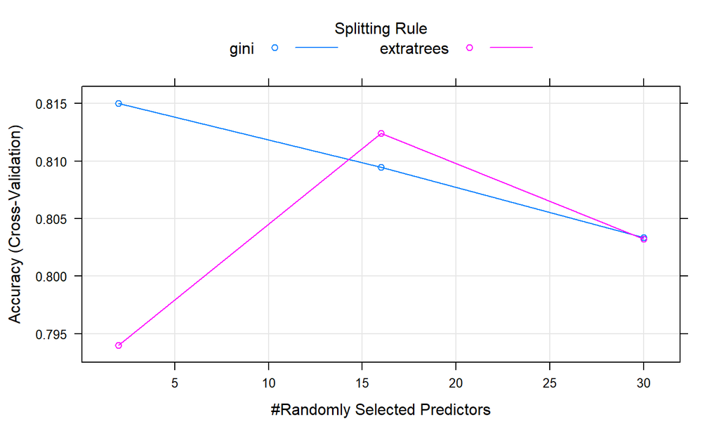

```r
plot(model5)
```

```r
cm5$overall[1]
```

```
##  Accuracy
## 0.8172904
```

```r
cm5$byClass[11]
```

```
## Balanced Accuracy
##         0.7449396
```

## Cross Validation with Ranger (training22)

## Results (3 fold cross validating w/ ranger; dummyVars and na.omit)

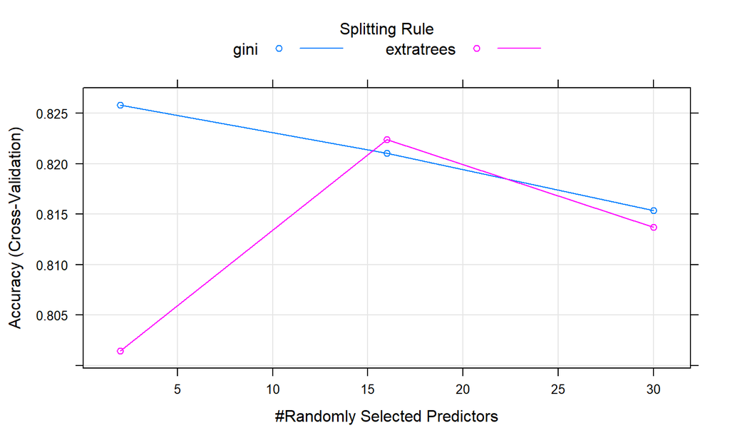

```r
plot(model6)
```

```r
cm6$overall[1]
```

```
##  Accuracy
## 0.8328683
```

```r
cm6$byClass[11]
```

```
## Balanced Accuracy
##         0.7574809
```

## Tuned Models (training11)

## Results (Tuned models of dummyVars w/ mean/mode)

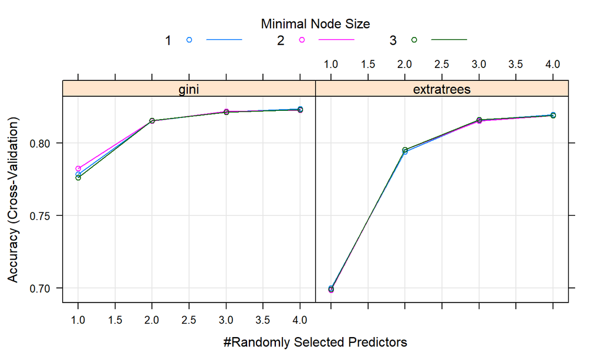

```r
plot(model7)
```

```r
cm7$overall[1]
```

```
##  Accuracy
## 0.8257467
```

```r
cm7$byClass[11]
```

```
## Balanced Accuracy
##         0.7680466
```

## Tuned Models (training2)

## Results (Tuned model of dummyVars w/ na.omit)

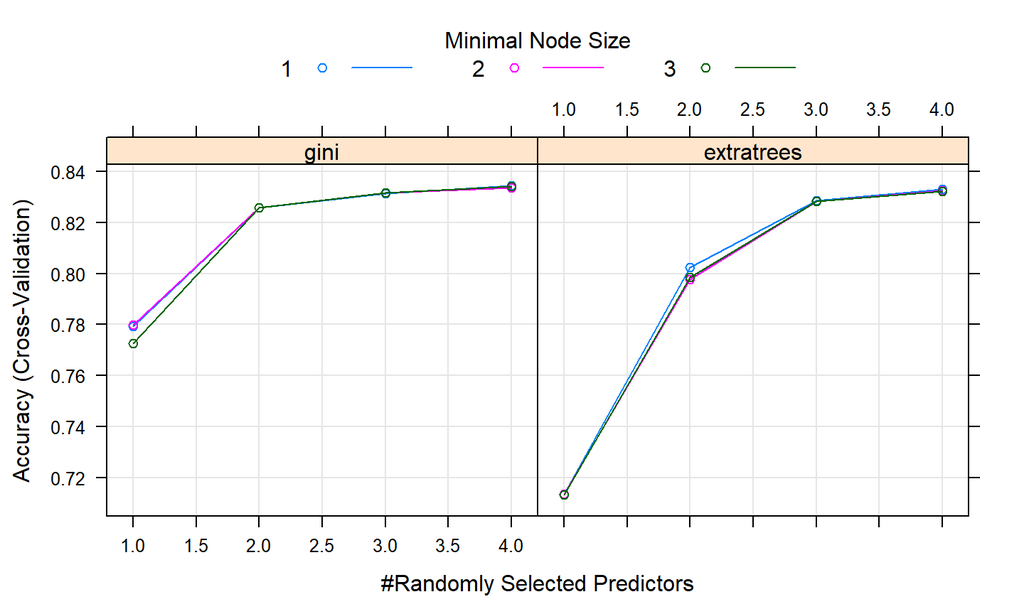

```r
plot(model8)
```

```r
cm8$overall[1]
```

```
##  Accuracy
## 0.8369141
```

```r
cm8$byClass[11]
```

```
## Balanced Accuracy
##         0.7745583
```